# Statistical Analysis on Diet Plans

Anirudh Dahiya

```r
library(tidyverse)
library(dplyr)
options(width=100)
```

# Section 1

#Data Ingestion

```r
#Reading dataset
diet_data <- read_csv("adult_diet_data.csv", guess_max = 10000)

#Reviewing dataset
str(diet_data)
```

```
## spec_tbl_df [400 × 8] (S3: spec_tbl_df/tbl_df/tbl/data.frame)
##  $ height      : num [1:400] 180 158 161 179 171 ...
##  $ start_weight: num [1:400] 92 57 59 67 64 60 74 63 65 79 ...
##  $ end_weight  : num [1:400] 86 57 58 67 61 61 70 61 65 83 ...
##  $ age         : num [1:400] 50 53 45 57 52 45 44 47 29 49 ...
##  $ sex         : chr [1:400] "M" "F" "F" "F" ...
##  $ impulsivity : num [1:400] 1.83 1.14 3.47 3.68 1.63 4.37 0.99 2.4 3.66 2.4 ...
##  $ diet_cond   : chr [1:400] "no_chocolate" "regular" "regular" "no_chocolate" ...
##  $ iq          : num [1:400] 71 82 72 110 104 112 106 82 104 112 ...
##  - attr(*, "spec")=
##   .. cols(
##   ..   height = col_double(),
##   ..   start_weight = col_double(),
##   ..   end_weight = col_double(),
##   ..   age = col_double(),
##   ..   sex = col_character(),
##   ..   impulsivity = col_double(),
##   ..   diet_cond = col_character(),
##   ..   iq = col_double()
##   .. )
##  - attr(*, "problems")=<externalptr>
```

```r
#Converting 'sex' and 'diet_cond' field values into factors since they're categorical variables
diet_data$sex <- as.factor(diet_data$sex)
diet_data$diet_cond <- as.factor(diet_data$diet_cond)
str(diet_data)
```

```
## spec_tbl_df [400 × 8] (S3: spec_tbl_df/tbl_df/tbl/data.frame)
##  $ height      : num [1:400] 180 158 161 179 171 ...
##  $ start_weight: num [1:400] 92 57 59 67 64 60 74 63 65 79 ...
##  $ end_weight  : num [1:400] 86 57 58 67 61 61 70 61 65 83 ...
##  $ age         : num [1:400] 50 53 45 57 52 45 44 47 29 49 ...
##  $ sex         : Factor w/ 2 levels "F","M": 2 1 1 1 1 1 1 1 2 2 ...
##  $ impulsivity : num [1:400] 1.83 1.14 3.47 3.68 1.63 4.37 0.99 2.4 3.66 2.4 ...
##  $ diet_cond   : Factor w/ 2 levels "no_chocolate",..: 1 2 2 1 2 2 1 2 2 2 ...
##  $ iq          : num [1:400] 71 82 72 110 104 112 106 82 104 112 ...
##  - attr(*, "spec")=
##   .. cols(
##   ..   height = col_double(),
##   ..   start_weight = col_double(),
##   ..   end_weight = col_double(),
##   ..   age = col_double(),
##   ..   sex = col_character(),
##   ..   impulsivity = col_double(),
##   ..   diet_cond = col_character(),
##   ..   iq = col_double()
##   .. )
##  - attr(*, "problems")=<externalptr>
```

```r
summary(diet_data)
```

```
##      height        start_weight      end_weight          age        sex      impulsivity
##  Min.   : 141.9   Min.   : 52.00   Min.   : 43.00   Min.   :18.00   F:200   Min.   :0.100
##  1st Qu.: 160.4   1st Qu.: 63.00   1st Qu.: 61.00   1st Qu.:39.00   M:200   1st Qu.:1.847
##  Median : 169.5   Median : 68.00   Median : 67.00   Median :45.00           Median :2.445
##  Mean   : 173.5   Mean   : 69.14   Mean   : 68.22   Mean   :45.43           Mean   :2.438
##  3rd Qu.: 178.3   3rd Qu.: 75.00   3rd Qu.: 75.00   3rd Qu.:52.00           3rd Qu.:3.010
##  Max.   :1636.3   Max.   :106.00   Max.   :105.00   Max.   :71.00           Max.   :5.420
##         diet_cond         iq
##  no_chocolate:148   Min.   : 59
##  regular     :252   1st Qu.: 91
##                     Median :102
##                     Mean   :101
##                     3rd Qu.:110
##                     Max.   :148
```

```r
#Removing Outlier - Data cleansing
#Upon applying the summary function on the dataset an outlier can clearly be noticed since the maximum value for the height column has been identified as - 1636.3cm which is not realistic/possible.
diet_data_processed <- filter(diet_data, diet_data$height != '1636.3')
#Other columns in the dataset seem to contain appropriate data, hence not plotting the dataset as a histogram to check for more outliers

#For renaming axes in plots.
Labels <- c('M' = "Males",'F' = "Females", 'no_chocolate'="No Chocolate Diet", 'regular'="Regular Diet")
```

# Data Dictionary

The following table describes the columns present in the dataset and the corresponding description elaborating on the kind of data present in each column.

| Variable | Description |
| --- | --- |
| height | Height of sample member in cm |
| start_weight | Weight in kg of sample member before trial |
| end_weight | Weight in kg of sample member at the end of trial |
| age | Age of sample member |
| sex | Gender of sample member |
| impulsivity | Score of sample member on an impulsivity test |
| diet_cond | Type of diet plan |
| iq | IQ of sample member |

#Question 1

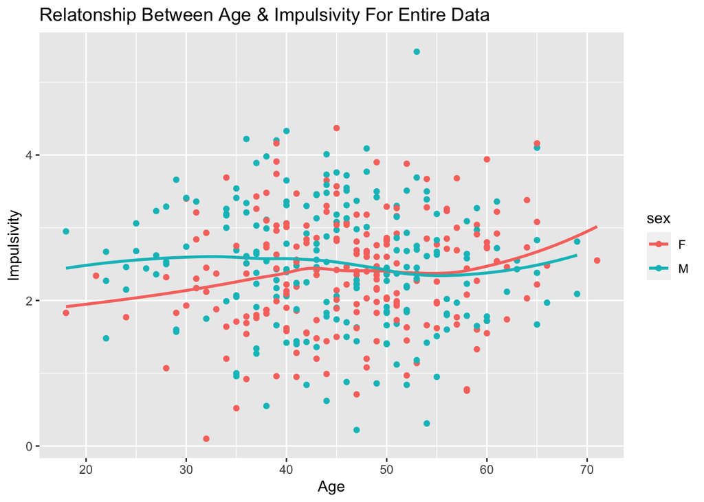

```r
#R code associated for the first request in the assignment
#Plotting a scatterplot for the overall dataset
( ques1_plot1 <- ggplot(data = diet_data_processed, mapping = aes(x = age, y = impulsivity, color = sex)) +
  geom_point() +
  geom_smooth(se=FALSE)+
  labs(x="Age", y="Impulsivity", title = "Relatonship Between Age & Impulsivity For Entire Data"))
```

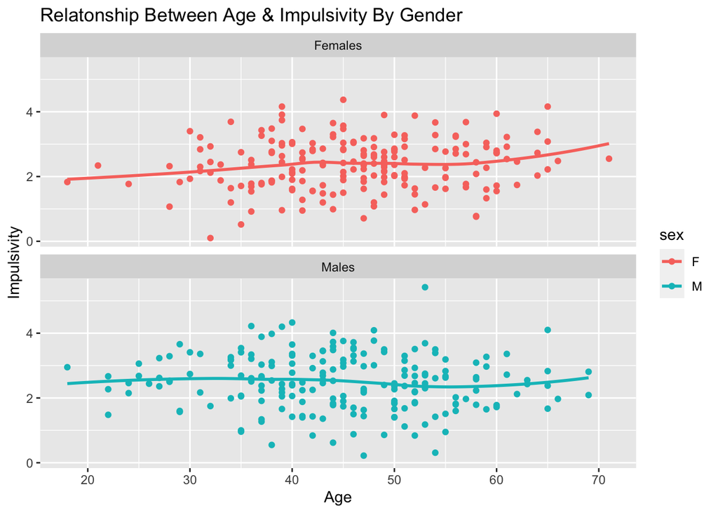

```r
#Plotting scatterplots for each gender
( ques1_plot2 <- ggplot(data = diet_data_processed, mapping = aes(x = age, y = impulsivity, color = sex)) +
  geom_point() +
  geom_smooth(se=FALSE)+
  facet_wrap(~sex, nrow =2, labeller = as_labeller(Labels))+
  labs(x="Age", y="Impulsivity", title = "Relatonship Between Age & Impulsivity By Gender") )
```

#Question 2

```r
#R code associated for the second request in the assignment
#Adding required calculated columns - 'starting_bmi', 'ending_bmi', 'total_weight_loss' to processed dataset
( diet_data_processed <- mutate(diet_data_processed, starting_bmi = diet_data_processed$start_weight/(diet_data_processed$height*0.01)^2, ending_bmi = diet_data_processed$end_weight/(diet_data_processed$height*0.01)^2, total_weight_loss = diet_data_processed$start_weight - diet_data_processed$end_weight) )
```

```
## # A tibble: 399 × 11
##    height start_weight end_weight   age sex   impulsivity diet_cond       iq starting_bmi ending_bmi
##     <dbl>        <dbl>      <dbl> <dbl> <fct>       <dbl> <fct>        <dbl>        <dbl>      <dbl>
##  1   180.           92         86    50 M            1.83 no_chocolate    71         28.5       26.6
##  2   158.           57         57    53 F            1.14 regular         82         22.9       22.9
##  3   161.           59         58    45 F            3.47 regular         72         22.8       22.4
##  4   179.           67         67    57 F            3.68 no_chocolate   110         20.8       20.8
##  5   171.           64         61    52 F            1.63 regular        104         21.9       20.9
##  6   166.           60         61    45 F            4.37 regular        112         21.8       22.2
##  7   156.           74         70    44 F            0.99 no_chocolate   106         30.4       28.7
##  8   152.           63         61    47 F            2.4  regular         82         27.1       26.3
##  9   175.           65         65    29 M            3.66 regular        104         21.1       21.1
## 10   181.           79         83    49 M            2.4  regular        112         24.1       25.3
## # … with 389 more rows, and 1 more variable: total_weight_loss <dbl>
```

```r
#Summary statistics for starting BMI
( start_bmi_calc_values <- diet_data_processed %>% group_by(sex, diet_cond) %>% summarise(mean = mean(starting_bmi), sd = sd(starting_bmi)) )
```

```
## # A tibble: 4 × 4
## # Groups:   sex [2]
##   sex   diet_cond     mean    sd
##   <fct> <fct>        <dbl> <dbl>
## 1 F     no_chocolate  25.6  3.82
## 2 F     regular       26.1  4.09
## 3 M     no_chocolate  22.8  3.57
## 4 M     regular       22.7  4.28
```

```r
#Summary statistics for ending BMI
( end_bmi_calc_values <- diet_data_processed %>% group_by(sex, diet_cond) %>% summarise(mean = mean(ending_bmi), sd = sd(ending_bmi)) )
```

```
## # A tibble: 4 × 4
## # Groups:   sex [2]
##   sex   diet_cond     mean    sd
##   <fct> <fct>        <dbl> <dbl>
## 1 F     no_chocolate  24.2  3.86
## 2 F     regular       26.3  4.33
## 3 M     no_chocolate  21.9  4.15
## 4 M     regular       22.8  4.66
```

```r
#Summary statistics for weight loss
( weight_loss_calc_values <- diet_data_processed %>% group_by(sex, diet_cond) %>% summarise(mean = mean(total_weight_loss), sd = sd(total_weight_loss)) )
```

```
## # A tibble: 4 × 4
## # Groups:   sex [2]
##   sex   diet_cond      mean    sd
##   <fct> <fct>         <dbl> <dbl>
## 1 F     no_chocolate  3.58   4.85
## 2 F     regular      -0.563  4.42
## 3 M     no_chocolate  2.78   5.27
## 4 M     regular      -0.206  4.50
```

#Question 3

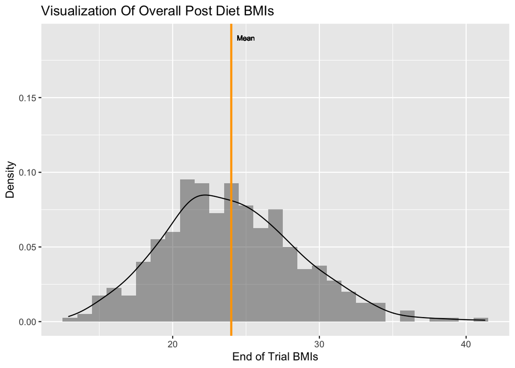

```r
#R code associated for the third request in the assignment
#Visualizing the overall distribution of post diet BMIs
( ques3_plot1 <- ggplot(diet_data_processed, aes(x=ending_bmi, y=..density..)) + geom_histogram(binwidth=1, alpha = 0.5) +
  geom_density()+
  labs(x="End of Trial BMIs", y="Density", title = "Visualization Of Overall Post Diet BMIs")+
  geom_vline(aes(xintercept=mean(ending_bmi)), colour="orange", size = 1)+
  geom_text(aes(x = mean(ending_bmi)+1, y = 0.19, label = "Mean"), size = 2.5, color = "black", show.legend = FALSE))
```

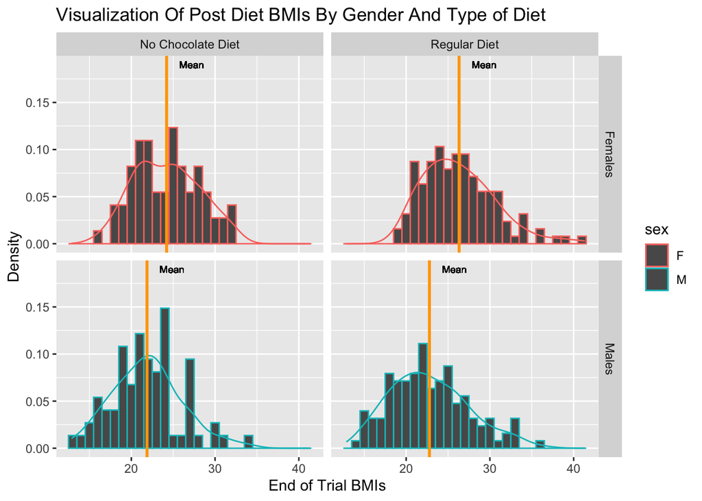

```r
#Visualizing the distributions of post diet BMIs for each gender and diet category by plotting a histogram and density plot
(ques3_plot2 <- ggplot(diet_data_processed, aes(x=ending_bmi, y=..density.., color = sex)) + geom_histogram(binwidth=1) +
  facet_grid(sex~diet_cond, labeller = as_labeller(Labels)) +
  geom_density()+
  labs(x="End of Trial BMIs", y="Density", title = "Visualization Of Post Diet BMIs By Gender And Type of Diet")+

  #plotting of mean post diet BMIs for each gender and diet category
  geom_vline(data=filter(diet_data_processed, sex=="M", diet_cond=='regular'), aes(xintercept=male_reg_diet_values$mean_end), colour="orange", size = 1)+
  geom_text(data=filter(diet_data_processed, sex=="M", diet_cond=='regular'), mapping = aes(x = male_reg_diet_values$mean_end+3, y = 0.19, label = "Mean"), size = 2.5, color = "black", show.legend = FALSE) +

geom_vline(data=filter(diet_data_processed, sex=="M", diet_cond=='no_chocolate'), aes(xintercept=male_no_choc_diet_values$mean_end), colour="orange", size = 1)+
  geom_text(data=filter(diet_data_processed, sex=="M", diet_cond=='no_chocolate'), mapping = aes(x = male_no_choc_diet_values$mean_end+3, y = 0.19, label = "Mean"), size = 2.5, color = "black", show.legend = FALSE) +

  geom_vline(data=filter(diet_data_processed, sex=="F", diet_cond=='regular'), aes(xintercept=female_reg_diet_values$mean_end), colour="orange", size = 1)+
  geom_text(data=filter(diet_data_processed, sex=="F", diet_cond=='regular'), mapping = aes(x = female_reg_diet_values$mean_end+3, y = 0.19, label = "Mean"), size = 2.5, color = "black", show.legend = FALSE) +

geom_vline(data=filter(diet_data_processed, sex=="F", diet_cond=='no_chocolate'), aes(xintercept=female_no_choc_diet_values$mean_end), colour="orange", size = 1)+
  geom_text(data=filter(diet_data_processed, sex=="F", diet_cond=='no_chocolate'), mapping = aes(x = female_no_choc_diet_values$mean_end+3, y = 0.19, label = "Mean"), size = 2.5, color = "black", show.legend = FALSE))
```

#Question 4

```r
#Reviewing diet data by weight loss and diet plan
( diet_data_by_weightloss <- diet_data_processed %>% group_by(diet_cond) %>%
  summarise(mean = mean(total_weight_loss), sd = sd(total_weight_loss, na.rm = TRUE), Count = n()) )
```

```
## # A tibble: 2 × 4
##   diet_cond      mean    sd Count
##   <fct>         <dbl> <dbl> <int>
## 1 no_chocolate  3.18   5.06   147
## 2 regular      -0.385  4.45   252
```

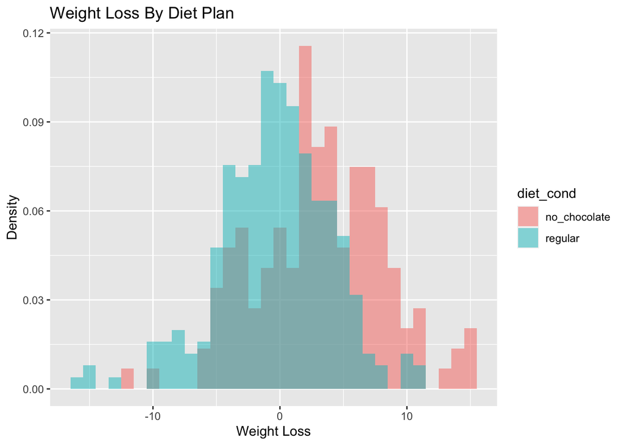

```r
#Since there is a difference in the mean of weight loss for each type of diet plan, plotting a histogram to have a look at how different their distributions are
( ques4_plot1 <- ggplot(diet_data_processed, aes(total_weight_loss,..density.., fill = diet_cond)) + geom_histogram(binwidth = 1, alpha = 0.5, position = "identity")+ labs(x = "Weight Loss", y = "Density", title = "Weight Loss By Diet Plan") )
```

```r
#Distributions of weight loss for each diet plan is different, hence performing t-test for further analysis
t.test(total_weight_loss ~ diet_cond, data = diet_data_processed)
```

```
##
##  Welch Two Sample t-test
##
## data:  total_weight_loss by diet_cond
## t = 7.0787, df = 274.81, p-value = 1.215e-11
## alternative hypothesis: true difference in means between group no_chocolate and group regular is not equal to 0
## 95 percent confidence interval:
##  2.571239 4.552343
## sample estimates:
## mean in group no_chocolate      mean in group regular
##                  3.1768707                 -0.3849206
```

# Section 2

#Report

1. A plot showing the relationship between impulsivity and age.

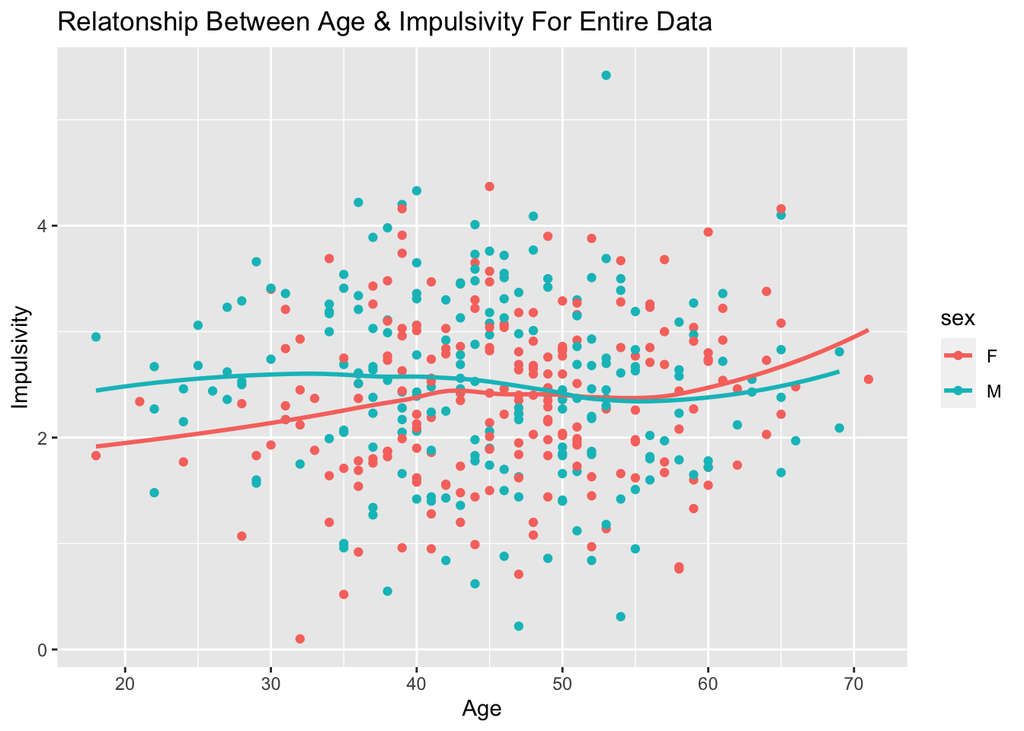

The above scatterplot confirms the suspicion held by the board that the relationship between age and impulsivity for the sample is non-linear. The loess lines created for the sample males and females are curved, thus indicating that a change in age is not directly proportional to a change in impulsivity. For example - The plot clearly displays how with increasing age, increasing impulsivity is not necessary, hence this confirms that the relationship is non-linear.

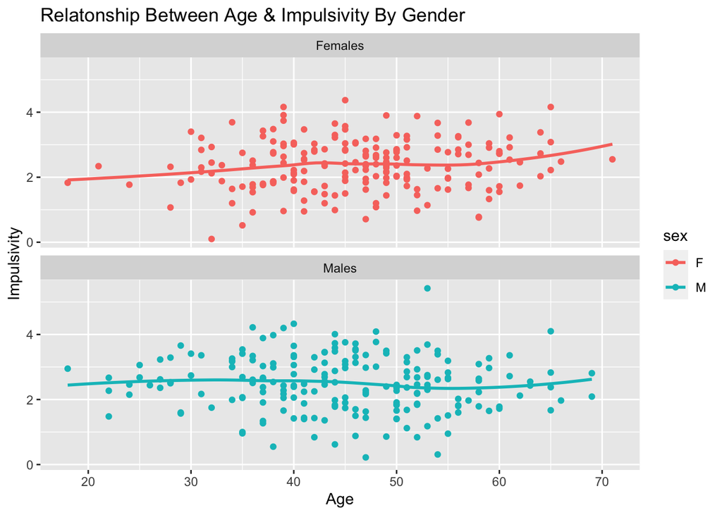

2. Summary statistics for BMI at the end of the trial

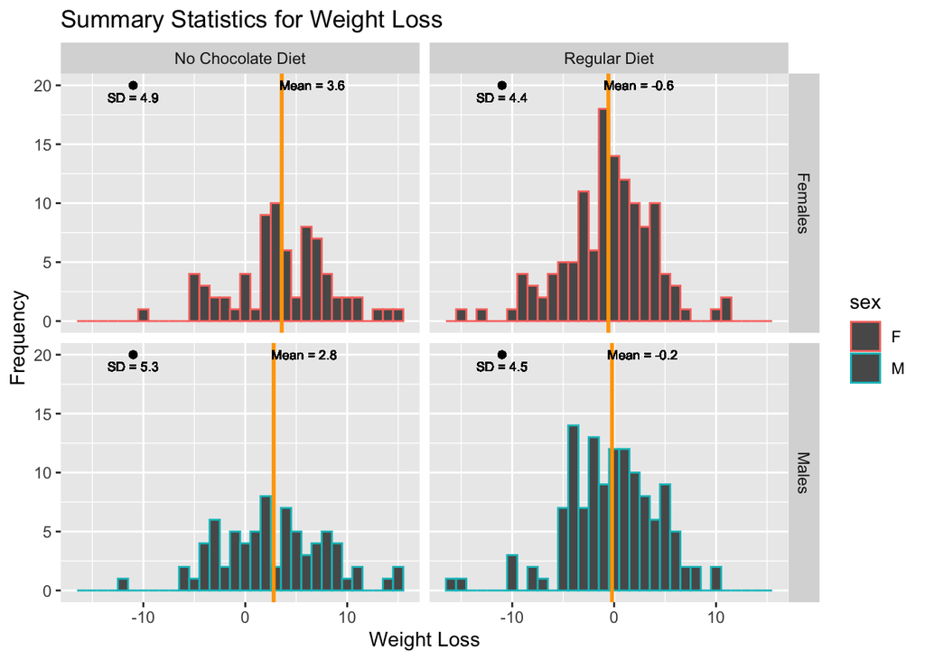

The above summary statistics for weight loss reveal that while some men and women that chose the regular diet achieved weight loss the average weight loss for the people that took up the regular diet is still very low. Hence the regular diet plan had little success in helping people through their weight loss journey when compared to the no chocolate diet.

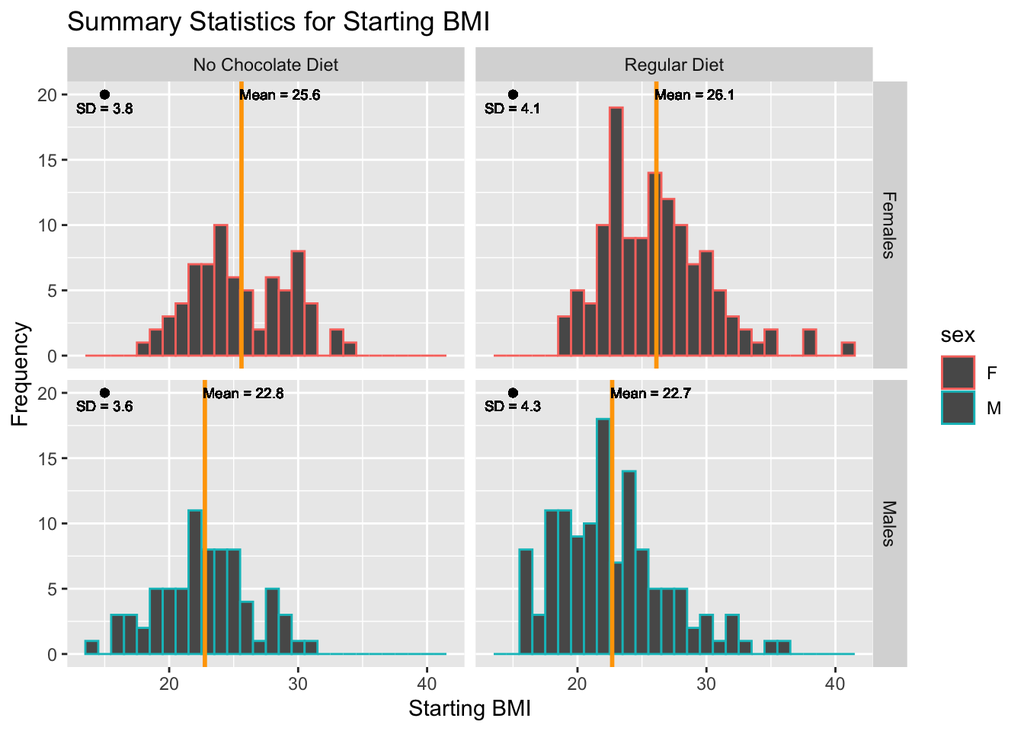

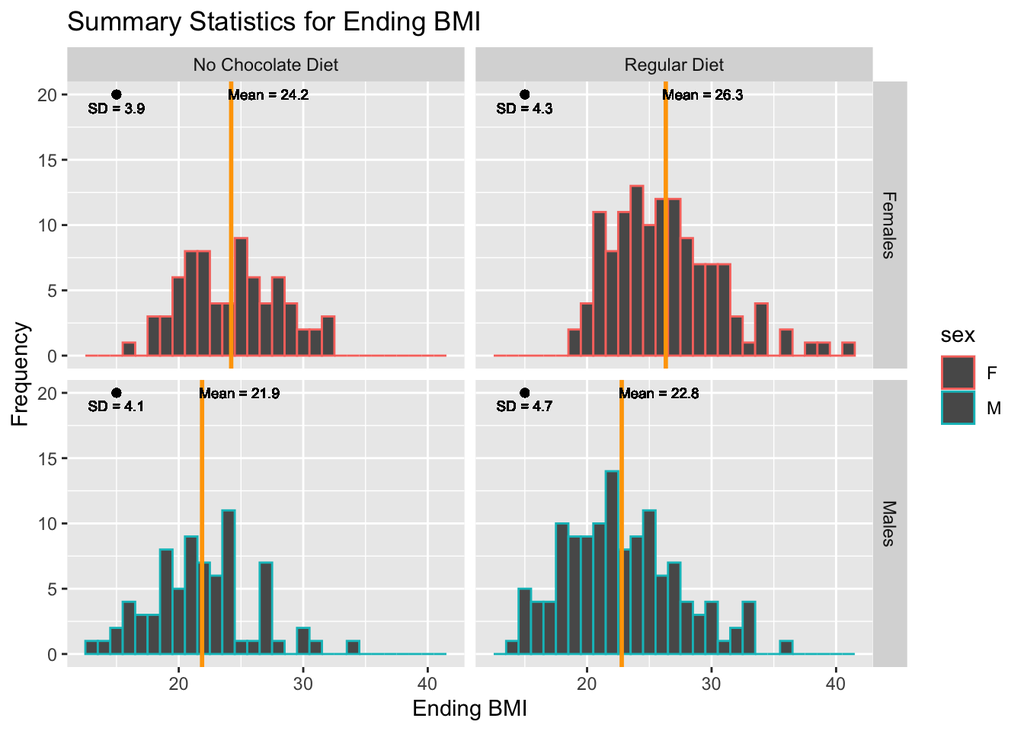

After calculating the summary statistics for the starting and ending BMIs separately for each sex and diet plan, it can be concluded that men and women that took up the no chocolate diet had a healthier mean BMI therefore they lost more weight than the men and women that took up the regular diet. The average BMIs for the men and women that took up the regular diet have a very marginal change post diet compared to their pre diet BMIs.

3. Visualization of the distribution of Post-Diet BMI

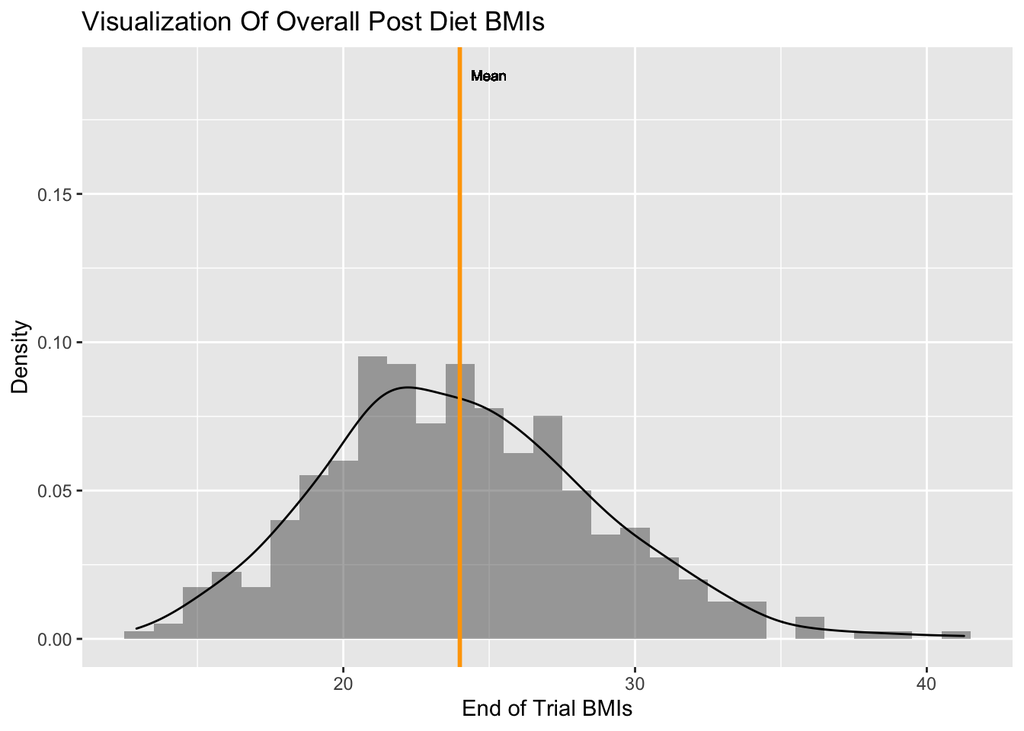

Comparison of post diet BMIs for each gender and diet plan is given below -

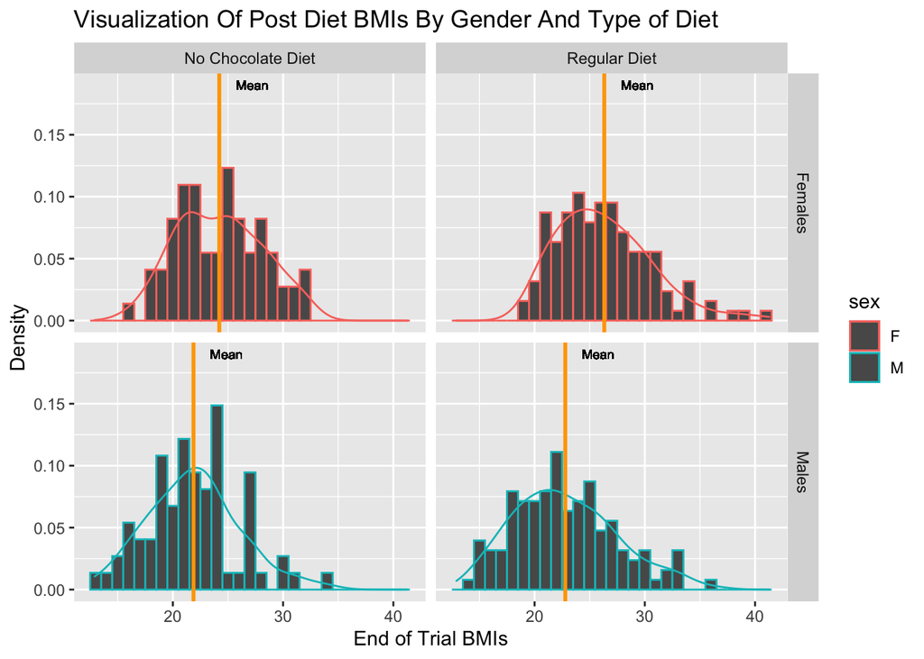

4. t-test comparing diet plans

From the sample the average weight loss for people that took up the no chocolate diet is 3.17 whereas the average weight loss for people that took up the regular diet is -0.38. The mean weight loss is significantly larger for people that took up the no chocolate diet, Welch t(275) = 7.07, p<0.00001. Since the p value is extremely small we can conclude that the average for both diet plans are significantly different and since their difference in averages is not zero we can reject the null hypothesis.

In all likelihood the weight loss associated with each diet plan will belong to a separate normal distribution indicating that there is a difference between both populations (people who took up the no chocolate diet and people who took up the regular diet). This is displayed in the graph below -

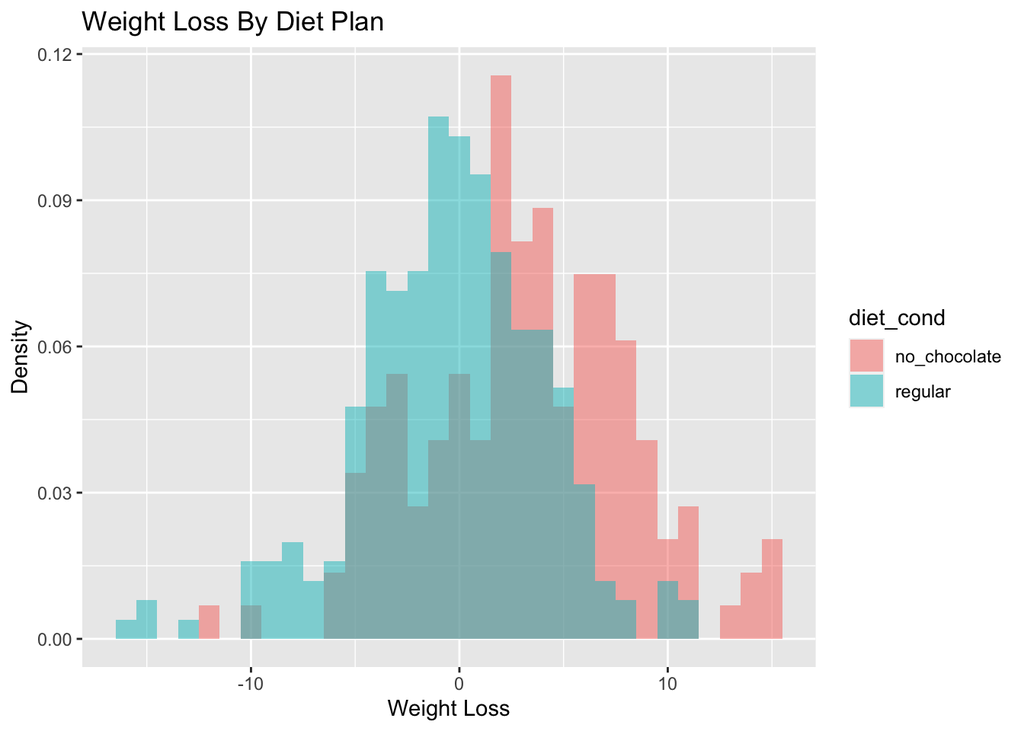